# Social Science—Parsing Personalities

# Foundational Concepts

In this lecture, we’ll discuss two statistical issues that arise from the social sciences.

```r
if (!caracas::has_sympy()) {
  caracas::install_sympy()
}
library(caracas)
library(sets)
library(tibble)
library(ggplot2)
library(dplyr)
```

```r
def_sym("X", "Y")

cmStats <- modules::use("CmStats.R")$cmStats

questionnaire <- jsonlite::fromJSON("./mbti_data_set/questionnaire_schema.json")
read_csv("./mbti_data_set/questionnaire_schema.json")
```

[output not shown]

[output cut: 990 more lines]

```r
NA
```

Social policy and social sciences rely on the interpretation of statistical data. This lecture discusses two separate topics related to the application of statistics to social science. The rst is a statistical technique, factor analysis, which can shed light on what quality several correlated, measured quantities all might be measuring. The technique seeks to identify underlying latent factors that explain correlation among a larger group of measured quantities. The other topic is possible limitations of hypothesis testing.

### factor analysis

Factor analysis is a statistical technique that tries to nd whether data comprising a number of variables can be summarized, or explained, by a smaller number of “factors.” Charles Spearman, studying intelligence, is credited with inventing the technique of factor analysis about 100 years ago. He hypothesized that there is one underlying factor of general intelligence (called the g factor) that underlies results of various other measures of mathematical and verbal skills.

The assumption underlying factor analysis is that there is a small group of latent factors that accounts for the correlation among a larger group of observed variables. For example, a questionnaire might ask 50 questions about emotions, each with a numeric answer, such as, “How much fear are you feeling?” “How much control are you feeling?” and so on, yielding 50 observed variables. The factors found in factor analysis are chosen specifically so that they have no correlation. They represent independent characteristics (of a person).

### MBTI: Myers-Briggs Personality Type Indicator

We’ll begin by looking at the famous Myers-Briggs Personality Type Indicator. After answering about 100 multiple-choice questions, the Myers- Briggs test presents us with a summary of our personality or preferences using four scales: (1) extraversion/introversion, (2) sensing/intuition, (3) thinking/ feeling, and (4) judging/perceiving. The results show us where on each scale our answers put us. A technique called factor analysis, though not used historically in the development of the Myers-Briggs indicators, describes how the 100 questions give rise to four axes. The idea is that the answers to the 100 questions can be combined in speci c ways to reveal a separate rating for extraversion/ introversion; another combination gives the answer to thinking/feeling, and so on.

```r
question_answers_df <- tibble(
  question = mapply(\(t) t$value[2], questionnaire$text),
  position_1 = mapply(\(d) d$value[2], mapply(\(t) t$text[1], questionnaire$answers)),
  position_2 =   mapply(\(d) d$value[2], mapply(\(t) t$text[2], questionnaire$answers))
  )

head(question_answers_df)
```

| question | position_1 | position_2 |
| --- | --- | --- |
| Usually you: | communicative | quite restrained and calm |
| If you were a teacher, with great pleasure you would lead: | practical lessons | theoretical studies |
| You more often allow: | feelings control your mind | the mind to control your feelings |
| When you decide to go somewhere for one day, you usually: | plan what and when you will do | just hit the road |
| Being in a company you usually: | join the conversation | talk with each separately |
| It is usually easier for you to communicate: | with people prone to fantasies | with realistic people |

```r
head(kpmi_data)
```

| jobtitle | jobfield | q1 | q2 | q3 | q4 | q5 | q6 | q7 | q8 | q9 | q10 | q11 | q12 | q13 | q14 | q15 | q16 | q17 | q18 | q19 | q20 | q21 | q22 | q23 | q24 | q25 | q26 | q27 | q28 | … |
| --- | --- | --- | --- | --- | --- | --- | --- | --- | --- | --- | --- | --- | --- | --- | --- | --- | --- | --- | --- | --- | --- | --- | --- | --- | --- | --- | --- | --- | --- | --- |
| NA | NA | 1 | 0 | 0 | 0 | 0 | 1 | 1 | 0 | 1 | 0 | 1 | 0 | 1 | 0 | 0 | 0 | 0 | 0 | 1 | 1 | 1 | 1 | 0 | 1 | 1 | 0 | 0 | 0 | … |
| HR manager | Staff and training | 1 | 0 | 0 | 1 | 1 | 1 | 1 | 0 | 1 | 0 | 1 | 0 | 0 | 0 | 1 | 1 | 1 | 1 | 1 | 0 | 0 | 1 | 0 | 1 | 1 | 1 | 1 | 0 | … |
| HR manager | Staff and training | 0 | 0 | 1 | 0 | 0 | 1 | 1 | 0 | 0 | 1 | 1 | 0 | 0 | 1 | 1 | 0 | 1 | 0 | 1 | 0 | 0 | 0 | 0 | 0 | 1 | 1 | 0 | 1 | … |
| HR manager | Staff and training | 0 | 0 | 1 | 1 | 0 | 1 | 1 | 0 | 0 | 0 | 0 | 1 | 0 | 0 | 1 | 0 | 1 | 0 | 1 | 1 | 0 | 1 | 0 | 0 | 1 | 0 | 0 | 0 | … |
| HR manager | Staff and training | 0 | 0 | 0 | 0 | 0 | 1 | 1 | 0 | 0 | 1 | 0 | 1 | 0 | 1 | 0 | 0 | 1 | 0 | 1 | 0 | 0 | 0 | 0 | 1 | 1 | 0 | 0 | 0 | … |
| HR manager | Staff and training | 0 | 1 | 1 | 0 | 0 | 1 | 1 | 1 | 1 | 0 | 1 | 0 | 1 | 1 | 0 | 1 | 1 | 0 | 0 | 1 | 0 | 0 | 0 | 0 | 1 | 1 | 1 | 1 | … |

```r
unique(kpmi_data$response_var)
```

```
[1] NA
```

```r
sum(is.na(kpmi_data$response_var))
```

```
[1] 21846
```

```r
sum(is.infinite(kpmi_data$response_var))
```

```
[1] 0
```

```r
sum(is.nan(kpmi_data$response_var))
```

```
[1] 0
```

```r
typeof(kpmi_data$scale_i)
```

```
[1] "double"
```

```r
kpmi_data$response_var <- as.factor(kpmi_data$psychotype)
```

```r
model_1 <-  lm( cbind(kpmi_data$scale_e, kpmi_data$scale_i) ~ kpmi_data$psychotype, data = kpmi_data)
anova(model_1)
```

```
Analysis of Variance Table

                        Df  Pillai approx F num Df den Df    Pr(>F)
(Intercept)              1 0.99574  2551584      2  21829 < 2.2e-16
kpmi_data$psychotype    15 0.68667      761     30  43660 < 2.2e-16
Residuals            21830

(Intercept)          ***
kpmi_data$psychotype ***
Residuals
---
Signif. codes:  0 ‘***’ 0.001 ‘**’ 0.01 ‘*’ 0.05 ‘.’ 0.1 ‘ ’ 1
```

```r
model_2 <-  lm( cbind(kpmi_data$scale_e, kpmi_data$scale_i, kpmi_data$scale_s, kpmi_data$scale_n) ~ kpmi_data$psychotype, data = kpmi_data)
summary.aov(model_2)
```

```
 Response 1 :
                        Df Sum Sq Mean Sq F value    Pr(>F)
kpmi_data$psychotype    15 564133   37609  2519.5 < 2.2e-16 ***
Residuals            21830 325861      15
---
Signif. codes:  0 ‘***’ 0.001 ‘**’ 0.01 ‘*’ 0.05 ‘.’ 0.1 ‘ ’ 1

 Response 2 :
                        Df Sum Sq Mean Sq F value    Pr(>F)
kpmi_data$psychotype    15 562238   37483  2499.2 < 2.2e-16 ***
Residuals            21830 327409      15
---
Signif. codes:  0 ‘***’ 0.001 ‘**’ 0.01 ‘*’ 0.05 ‘.’ 0.1 ‘ ’ 1

 Response 3 :
                        Df Sum Sq Mean Sq F value    Pr(>F)
kpmi_data$psychotype    15 493950   32930  2139.1 < 2.2e-16 ***
Residuals            21830 336063      15
---
Signif. codes:  0 ‘***’ 0.001 ‘**’ 0.01 ‘*’ 0.05 ‘.’ 0.1 ‘ ’ 1

 Response 4 :
                        Df Sum Sq Mean Sq F value    Pr(>F)
kpmi_data$psychotype    15 453190   30213  2332.9 < 2.2e-16 ***
Residuals            21830 282714      13
---
Signif. codes:  0 ‘***’ 0.001 ‘**’ 0.01 ‘*’ 0.05 ‘.’ 0.1 ‘ ’ 1
```

```r
model_3 <-  manova( cbind(kpmi_data$q1, kpmi_data$q2, kpmi_data$q3, kpmi_data$q4) ~ kpmi_data$psychotype, data = kpmi_data)
summary.aov(model_3)
```

```
 Response 1 :
                        Df Sum Sq Mean Sq F value    Pr(>F)
kpmi_data$psychotype    15 1703.4  113.56  709.97 < 2.2e-16 ***
Residuals            21830 3491.8    0.16
---
Signif. codes:  0 ‘***’ 0.001 ‘**’ 0.01 ‘*’ 0.05 ‘.’ 0.1 ‘ ’ 1

 Response 2 :
                        Df Sum Sq Mean Sq F value    Pr(>F)
kpmi_data$psychotype    15  221.1 14.7380  79.581 < 2.2e-16 ***
Residuals            21830 4042.8  0.1852
---
Signif. codes:  0 ‘***’ 0.001 ‘**’ 0.01 ‘*’ 0.05 ‘.’ 0.1 ‘ ’ 1

 Response 3 :
                        Df Sum Sq Mean Sq F value    Pr(>F)
kpmi_data$psychotype    15  677.7  45.181  233.71 < 2.2e-16 ***
Residuals            21830 4220.2   0.193
---
Signif. codes:  0 ‘***’ 0.001 ‘**’ 0.01 ‘*’ 0.05 ‘.’ 0.1 ‘ ’ 1

 Response 4 :
                        Df Sum Sq Mean Sq F value    Pr(>F)
kpmi_data$psychotype    15  926.5  61.768  362.53 < 2.2e-16 ***
Residuals            21830 3719.4   0.170
---
Signif. codes:  0 ‘***’ 0.001 ‘**’ 0.01 ‘*’ 0.05 ‘.’ 0.1 ‘ ’ 1
```

```r
model_4 <-  manova(
  cbind(kpmi_data$scale_e, kpmi_data$scale_i, kpmi_data$scale_s, kpmi_data$scale_n,
        kpmi_data$scale_t, kpmi_data$scale_f) ~ kpmi_data$psychotype, data = kpmi_data)
summary.aov(model_4)
```

```
 Response 1 :
                        Df Sum Sq Mean Sq F value    Pr(>F)
kpmi_data$psychotype    15 564133   37609  2519.5 < 2.2e-16 ***
Residuals            21830 325861      15
---
Signif. codes:  0 ‘***’ 0.001 ‘**’ 0.01 ‘*’ 0.05 ‘.’ 0.1 ‘ ’ 1

 Response 2 :
                        Df Sum Sq Mean Sq F value    Pr(>F)
kpmi_data$psychotype    15 562238   37483  2499.2 < 2.2e-16 ***
Residuals            21830 327409      15
---
Signif. codes:  0 ‘***’ 0.001 ‘**’ 0.01 ‘*’ 0.05 ‘.’ 0.1 ‘ ’ 1

 Response 3 :
                        Df Sum Sq Mean Sq F value    Pr(>F)
kpmi_data$psychotype    15 493950   32930  2139.1 < 2.2e-16 ***
Residuals            21830 336063      15
---
Signif. codes:  0 ‘***’ 0.001 ‘**’ 0.01 ‘*’ 0.05 ‘.’ 0.1 ‘ ’ 1

 Response 4 :
                        Df Sum Sq Mean Sq F value    Pr(>F)
kpmi_data$psychotype    15 453190   30213  2332.9 < 2.2e-16 ***
Residuals            21830 282714      13
---
Signif. codes:  0 ‘***’ 0.001 ‘**’ 0.01 ‘*’ 0.05 ‘.’ 0.1 ‘ ’ 1

 Response 5 :
                        Df Sum Sq Mean Sq F value    Pr(>F)
kpmi_data$psychotype    15 534837   35656  2049.4 < 2.2e-16 ***
Residuals            21830 379796      17
---
Signif. codes:  0 ‘***’ 0.001 ‘**’ 0.01 ‘*’ 0.05 ‘.’ 0.1 ‘ ’ 1

 Response 6 :
                        Df Sum Sq Mean Sq F value    Pr(>F)
kpmi_data$psychotype    15 454423 30294.9  2058.1 < 2.2e-16 ***
Residuals            21830 321337    14.7
---
Signif. codes:  0 ‘***’ 0.001 ‘**’ 0.01 ‘*’ 0.05 ‘.’ 0.1 ‘ ’ 1
```

```r
model_5 <-  manova(
  cbind(kpmi_data$scale_e, kpmi_data$scale_i, kpmi_data$scale_s, kpmi_data$scale_n,
        kpmi_data$scale_t, kpmi_data$scale_f, kpmi_data$scale_j, kpmi_data$scale_p) ~ kpmi_data$psychotype, data = kpmi_data)
summary.aov(model_5)
```

```
 Response 1 :
                        Df Sum Sq Mean Sq F value    Pr(>F)
kpmi_data$psychotype    15 564133   37609  2519.5 < 2.2e-16 ***
Residuals            21830 325861      15
---
Signif. codes:  0 ‘***’ 0.001 ‘**’ 0.01 ‘*’ 0.05 ‘.’ 0.1 ‘ ’ 1

 Response 2 :
                        Df Sum Sq Mean Sq F value    Pr(>F)
kpmi_data$psychotype    15 562238   37483  2499.2 < 2.2e-16 ***
Residuals            21830 327409      15
---
Signif. codes:  0 ‘***’ 0.001 ‘**’ 0.01 ‘*’ 0.05 ‘.’ 0.1 ‘ ’ 1

 Response 3 :
                        Df Sum Sq Mean Sq F value    Pr(>F)
kpmi_data$psychotype    15 493950   32930  2139.1 < 2.2e-16 ***
Residuals            21830 336063      15
---
Signif. codes:  0 ‘***’ 0.001 ‘**’ 0.01 ‘*’ 0.05 ‘.’ 0.1 ‘ ’ 1

 Response 4 :
                        Df Sum Sq Mean Sq F value    Pr(>F)
kpmi_data$psychotype    15 453190   30213  2332.9 < 2.2e-16 ***
Residuals            21830 282714      13
---
Signif. codes:  0 ‘***’ 0.001 ‘**’ 0.01 ‘*’ 0.05 ‘.’ 0.1 ‘ ’ 1

 Response 5 :
                        Df Sum Sq Mean Sq F value    Pr(>F)
kpmi_data$psychotype    15 534837   35656  2049.4 < 2.2e-16 ***
Residuals            21830 379796      17
---
Signif. codes:  0 ‘***’ 0.001 ‘**’ 0.01 ‘*’ 0.05 ‘.’ 0.1 ‘ ’ 1

 Response 6 :
                        Df Sum Sq Mean Sq F value    Pr(>F)
kpmi_data$psychotype    15 454423 30294.9  2058.1 < 2.2e-16 ***
Residuals            21830 321337    14.7
---
Signif. codes:  0 ‘***’ 0.001 ‘**’ 0.01 ‘*’ 0.05 ‘.’ 0.1 ‘ ’ 1

 Response 7 :
                        Df Sum Sq Mean Sq F value    Pr(>F)
kpmi_data$psychotype    15 668109   44541  2840.9 < 2.2e-16 ***
Residuals            21830 342258      16
---
Signif. codes:  0 ‘***’ 0.001 ‘**’ 0.01 ‘*’ 0.05 ‘.’ 0.1 ‘ ’ 1

 Response 8 :
                        Df Sum Sq Mean Sq F value    Pr(>F)
kpmi_data$psychotype    15 683067   45538  2767.6 < 2.2e-16 ***
Residuals            21830 359195      16
---
Signif. codes:  0 ‘***’ 0.001 ‘**’ 0.01 ‘*’ 0.05 ‘.’ 0.1 ‘ ’ 1
```

For example, in a study of jealousy, 20 measures of qualities were reduced to 3 factors, called by the researcher Reactive Jealousy, Anxious Suspicion, and Interpersonal Insecurity. The correlations between each of these 3 factors and the 20 original variables served to divide the 20 into 3 groups. The variables in the rst group are highly correlated to the rst factor and usually have low correlation with the other two factors, and so on. Part of the intent is that something has been learned about jealousy, namely, that there are 3 principal ingredients that underlie the original 20 variables. Care must be taken in interpretation, but insight can be gained about the psychological or social issue being studied, as reflected in the factors that are a good mathematical model or summary of the data.

### Bayesian statistics

We now turn to some issues concerning hypothesis testing. Hypothesis testing is an example of a strategy for testing features of our world, but some social scientists and many others feel that there has traditionally been too heavy a reliance on hypothesis testing as a way of adducing and interpreting evidence.

In the first experiment, a musicologist is presented with 10 pairs of sheet music, and he must determine if the composer is Mozart or Haydn. He is correct 10 times out of 10. We are already familiar with the second experiment of the lady tasting tea, in which a lady was able to taste 10 pairs of cups of tea with milk and tell correctly each time whether the milk or the tea had been poured in rst. In the third experiment, a drunk claims he can tell whether a coin will land heads or tails every time it is ipped. And, indeed, he does guess correctly 10 times out of 10.

Most people would say that the Mozart/Haydn experiment was very persuasive and the lady tasting tea less so. With the drunk person, we retain a good deal of skepticism. We are updating the prior assessment of our view of reality.

In the Bayesian point of view, we view our assessment of the world as a probability graph rather than a xed number. It is an interesting philosophical perspective that takes our everyday experience and captures it on a mathematically sound footing.

# Concept and Applications

## POLYNOMIAL AND LOGISTIC REGRESSION

Linear models can be used to model a variety of data and are relatively easy to fit in R. Applying transformations to data that might not fit the normality assumption gives us even more modeling flexibility. But what about data that still doesn’t conform to normality even after a transformation? Trees are one possibility, but even tree-fitting methods aren’t effective on data that doesn’t have natural splits. What can we do when we have data for which transformations and tree algorithms aren’t effective? In this lecture, you will learn about polynomial regression and logistic regression.

### POLYNOMIAL REGRESSION

Polynomial regression lets us extend the linear model by adding powers of predictors to our model. This gives us a clean way to give a nonlinear fit to our data.

Recall the standard linear model, where Y is modeled as 𝑦 = β0 + β1X1 + β2X2 + β3X3 + … + et, ( where the βs are coefficients and et is a term with 0 mean and normal distribution error ). Instead of predictors X1, X2, X3 …, we now have a polynomial function with predictor X, where Y is modeled as 𝑦 = β0 + β1X + β2X2 + β3X3 + … + et. This is known as polynomial regression.

Let’s look at an example in R.

|  | crim | zn | indus | chas | nox | rm | age | dis | rad | tax | ptratio | black | lstat | medv |
| --- | --- | --- | --- | --- | --- | --- | --- | --- | --- | --- | --- | --- | --- | --- |
| 1 | 0.00632 | 18 | 2.31 | 0 | 0.538 | 6.575 | 65.2 | 4.0900 | 1 | 296 | 15.3 | 396.90 | 4.98 | 24.0 |
| 2 | 0.02731 | 0 | 7.07 | 0 | 0.469 | 6.421 | 78.9 | 4.9671 | 2 | 242 | 17.8 | 396.90 | 9.14 | 21.6 |
| 3 | 0.02729 | 0 | 7.07 | 0 | 0.469 | 7.185 | 61.1 | 4.9671 | 2 | 242 | 17.8 | 392.83 | 4.03 | 34.7 |
| 4 | 0.03237 | 0 | 2.18 | 0 | 0.458 | 6.998 | 45.8 | 6.0622 | 3 | 222 | 18.7 | 394.63 | 2.94 | 33.4 |
| 5 | 0.06905 | 0 | 2.18 | 0 | 0.458 | 7.147 | 54.2 | 6.0622 | 3 | 222 | 18.7 | 396.90 | 5.33 | 36.2 |
| 6 | 0.02985 | 0 | 2.18 | 0 | 0.458 | 6.430 | 58.7 | 6.0622 | 3 | 222 | 18.7 | 394.12 | 5.21 | 28.7 |

Here are the variables in the dataset. Let’s restrict our attention to the last 2: the median house value for select neighborhoods in Boston ( medv ), which is the response variable, and the lower status of the population by percentage ( lsat ), which is the explanatory variable. Let’s use simple linear regression.

```r
lm_fit <- lm(medv ~ lstat, data = Boston)
summary(lm_fit)
```

```
Call:
lm(formula = medv ~ lstat, data = Boston)

Residuals:
    Min      1Q  Median      3Q     Max
-15.168  -3.990  -1.318   2.034  24.500

Coefficients:
            Estimate Std. Error t value Pr(>|t|)
(Intercept) 34.55384    0.56263   61.41   <2e-16 ***
lstat       -0.95005    0.03873  -24.53   <2e-16 ***
---
Signif. codes:  0 ‘***’ 0.001 ‘**’ 0.01 ‘*’ 0.05 ‘.’ 0.1 ‘ ’ 1

Residual standard error: 6.216 on 504 degrees of freedom
Multiple R-squared:  0.5441,    Adjusted R-squared:  0.5432
F-statistic: 601.6 on 1 and 504 DF,  p-value: < 2.2e-16
```

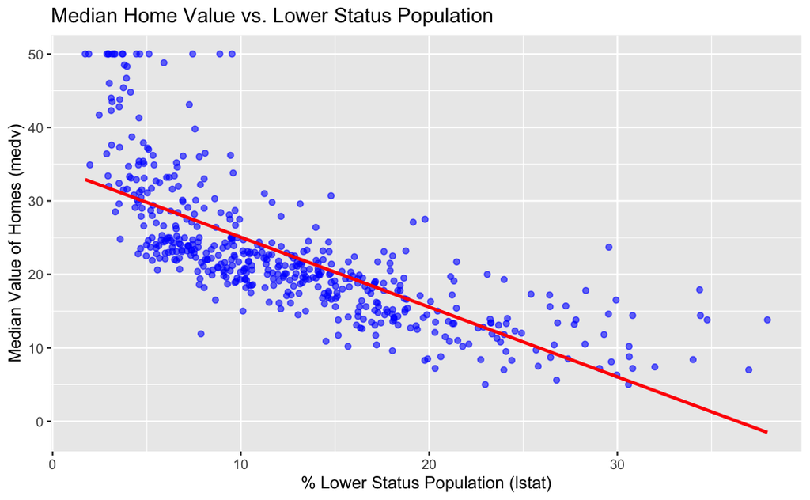

```r
ggplot(Boston, aes(x = lstat, y = medv)) +

  # A. Scatter plot of the raw data points
  geom_point(color = "blue", alpha = 0.6) +

  # B. Overlay the regression line
  # geom_smooth(method = "lm") automatically calculates and plots the lm.fit line
  geom_smooth(method = "lm", color = "red", se = FALSE) + # se=FALSE hides the confidence interval

  # C. Labels and Title
  labs(
    title = "Median Home Value vs. Lower Status Population",
    x = "% Lower Status Population (lstat)",
    y = "Median Value of Homes (medv)"
  )
```

The linear fit doesn’t fully capture the curvature of the data. A polynomial regression would give us flexibility to fit a nonlinear curve.

We can perform a regression of “medv” onto a quadratic polynomial of “lstat” by using this formula: medv ~ lstat + I( lstat^2 ).

```r
summary(lm(medv ~ lstat + I(lstat^2), data = Boston))
```

```
Call:
lm(formula = medv ~ lstat + I(lstat^2), data = Boston)

Residuals:
     Min       1Q   Median       3Q      Max
-15.2834  -3.8313  -0.5295   2.3095  25.4148

Coefficients:
             Estimate Std. Error t value Pr(>|t|)
(Intercept) 42.862007   0.872084   49.15   <2e-16 ***
lstat       -2.332821   0.123803  -18.84   <2e-16 ***
I(lstat^2)   0.043547   0.003745   11.63   <2e-16 ***
---
Signif. codes:  0 ‘***’ 0.001 ‘**’ 0.01 ‘*’ 0.05 ‘.’ 0.1 ‘ ’ 1

Residual standard error: 5.524 on 503 degrees of freedom
Multiple R-squared:  0.6407,    Adjusted R-squared:  0.6393
F-statistic: 448.5 on 2 and 503 DF,  p-value: < 2.2e-16
```

“lstat^2” looks like a variable name we forgot to define, so it gets ignored without the indicator function. The “I( )” function is necessary.

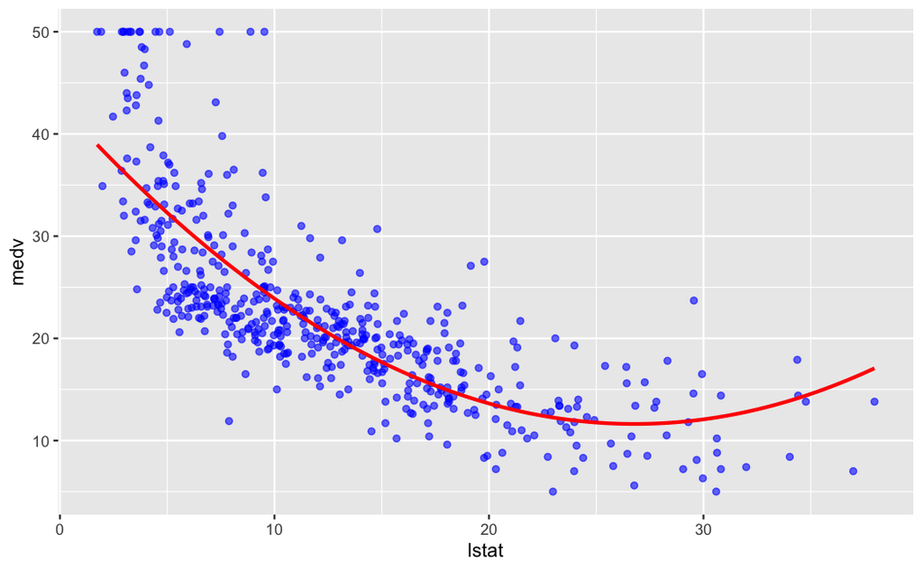

```r
ggplot(Boston, aes(x = lstat, y = medv)) +
  geom_point(color = "blue", alpha = 0.6) +
  geom_smooth(method = "lm", formula = y ~ x + I(x^2), color = "red", se = FALSE)
```

```r
  labs(
    title = "Median Home Value vs. Lower Status Population",
    x = "% Lower Status Population (lstat)",
    y = "Median Value of Homes (medv)"
  )
```

```
<ggplot2::labels> List of 3
 $ x    : chr "% Lower Status Population (lstat)"
 $ y    : chr "Median Value of Homes (medv)"
 $ title: chr "Median Home Value vs. Lower Status Population"
```

A higher-order model might give us a better fit. We can extend the polynomial out to 3 degrees to get an even more accurate fit of our data.

```r
summary(lm(medv ~ lstat + I(lstat^2) + I(lstat^3), data = Boston))
```

```
Call:
lm(formula = medv ~ lstat + I(lstat^2) + I(lstat^3), data = Boston)

Residuals:
     Min       1Q   Median       3Q      Max
-14.5441  -3.7122  -0.5145   2.4846  26.4153

Coefficients:
              Estimate Std. Error t value Pr(>|t|)
(Intercept) 48.6496253  1.4347240  33.909  < 2e-16 ***
lstat       -3.8655928  0.3287861 -11.757  < 2e-16 ***
I(lstat^2)   0.1487385  0.0212987   6.983 9.18e-12 ***
I(lstat^3)  -0.0020039  0.0003997  -5.013 7.43e-07 ***
---
Signif. codes:  0 ‘***’ 0.001 ‘**’ 0.01 ‘*’ 0.05 ‘.’ 0.1 ‘ ’ 1

Residual standard error: 5.396 on 502 degrees of freedom
Multiple R-squared:  0.6578,    Adjusted R-squared:  0.6558
F-statistic: 321.7 on 3 and 502 DF,  p-value: < 2.2e-16
```

We increase in R2 from 0.6393 to 0.6558 when going from a second- degree to a third-degree polynomial. It better models the tail end of our data, suggesting that home values would continue to decrease as low socioeconomic status increased.

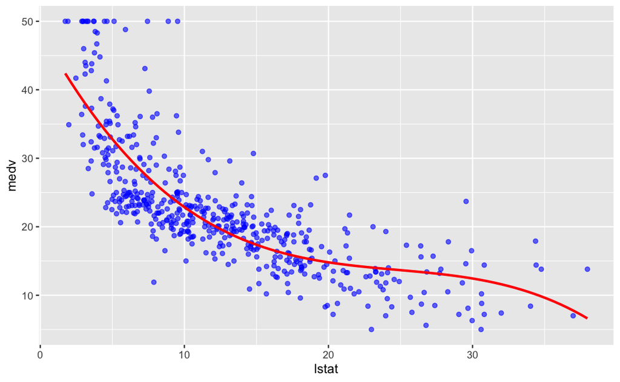

```r
ggplot(Boston, aes(x = lstat, y = medv)) +
  geom_point(color = "blue", alpha = 0.6) +
  geom_smooth(method = "lm", formula = y ~ poly(x, 3), color = "red", se = FALSE)
```

```r
  labs(
    title = "Median Home Value vs. Lower Status Population",
    x = "% Lower Status Population (lstat)",
    y = "Median Value of Homes (medv)"
  )
```

```
<ggplot2::labels> List of 3
 $ x    : chr "% Lower Status Population (lstat)"
 $ y    : chr "Median Value of Homes (medv)"
 $ title: chr "Median Home Value vs. Lower Status Population"
```

Why stop at a third-degree polynomial?

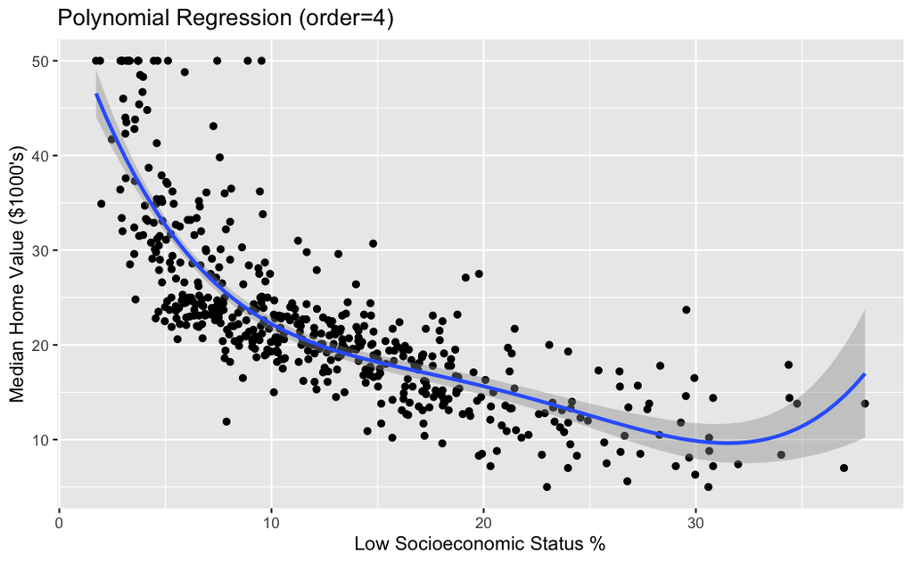

```r
qplot(data = Boston, x = lstat, y = medv,
xlab = "Low Socioeconomic Status %",
ylab = "Median Home Value ($1000's)") +
stat_smooth(method = "lm", formula = y ~ poly(x, 4)) +
ggtitle("Polynomial Regression (order=4)")
```

Here’s a fourth-degree polynomial, which seems to do a better job of fitting the data in the < 30% lstat range. But look what happens for lstat > 30%. We need to think about what this is saying because this model is suggesting questionable behavior. There’s no reason to believe that home values would increase as low socioeconomic status increased.

We continue with a fifth-degree fit. In fact, as we increase the polynomials, we fine-tune our fit to the data.

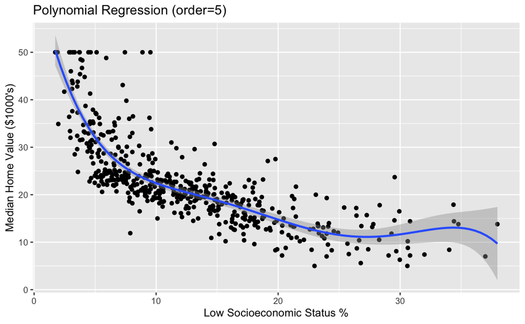

```r
qplot(data = Boston, x = lstat, y = medv,
xlab = "Low Socioeconomic Status %",
ylab = "Median Home Value ($1000's)") +
stat_smooth(method = "lm", formula = y ~ poly(x, 5)) +
ggtitle("Polynomial Regression (order=5)")
```

Let’s see what happens when we ramp up to the 15th-degree polynomial fit of our data.

```r
qplot(data = Boston, x = lstat, y = medv,
xlab = "Low Socioeconomic Status %",
ylab = "Median Home Value ($1000's)") +
stat_smooth(method = "lm", formula = y ~ poly(x, 15)) +
ggtitle("Polynomial Regression (order=15)")
```

[output not shown]

The danger in increasing the order of polynomials is that our model becomes overfit. An overfit model is one that’s too complicated to convey useful information from your dataset. In other words, the model becomes tailored to fit the nuances in our specific sample rather than reflecting the overall population.

Instead, we want our model to approximate the true model for the entire population. Our model shouldn’t just fit the current sample; it should fit new samples, too.

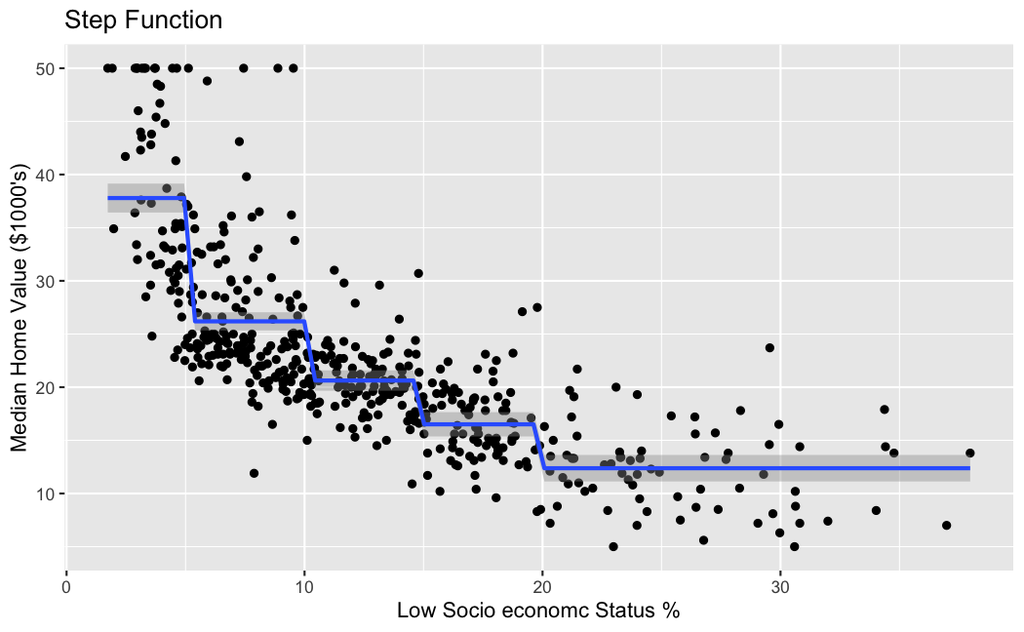

```r
qplot(data = Boston, x = lstat, y = medv,
xlab = "Low Socio economc Status %",
ylab = "Median Home Value ($1000's)") +
  stat_smooth(method = "lm", formula = y ~ cut(x, breaks = c(-Inf, 5 , 10, 15, 20, Inf))) + ggtitle("Step Function")
```

When comparing a third-degree polynomial, for example, with a step function, how do we decide which one is a better fit? We can take the R2 value for each and see which one is higher. We can also analyze the residuals of each, checking them for normality and linearity.

### LOGISTIC REGRESSION

Another class of cases where we might want to fit a model to nonlinear data is logistic regression. Often, we face the problem of modeling binary data. We might want to predict whether patients will live or die, species will thrive or go extinct, buildings will fall or stay standing, or a patient will accept or reject an organ transfer.

The problem is that we’re dealing with a probability, but the regression can easily give us illegal values less than 0 or greater than 1. Also, linear models don’t handle probabilities well. For example, smoking 2 cigarettes per day might double your risk of cancer compared to smoking 1 per day, but increasing from 11 to 12 per day may not make such a big difference. And once we predict that a patient has a 100% chance of an outcome, we’re maxed out, and no new information about the patient could improve his or her odds.

Another way of thinking about probabilities is to transform them using this function:

```r
cmStats$odds_sym
```

```
c:   p
   ─────
   1 - p
```

This is the probability of something happening divided by the probability of it not happening.

The odds give us a value that ranges from nearly 0 ( for very small probabilities ) to positive infinity ( for probabilities essentially at 1 ). But with one more transformation, we can get a value that’s unbounded over the real numbers. This is the logistic function: $𝑦 = log[𝑝/( 1 − 𝑝 )]$. Probabilities transformed through the logistic function are known as logit values.

The logistic regression is a regression model in which the response variable ( dependent variable ) has categorical values such as true/false or 0/1. It deals with measuring the probability of a binary response variable. In R, the function “glm( )” is used to create the logistic regression.

Logistic regression is a generalized linear model ( GLM ) that we use to model a binary categorical variable with numerical and categorical predictors. We assume that a binomial distribution produced the outcome variable and therefore want to model 𝑝, the probability of success for a given set of predictors.

In our case, there’s a variety of options, but the most commonly used is the logit function ( and the similar-looking probit function, which is based on a normal distribution ).

for $0 ≤ p ≤ 1$:

```r
cmStats$logit_sym
```

```
c:    ⎛  p  ⎞
   log⎜─────⎟
      ⎝1 - p⎠
```

The general mathematical equation for logistic regression is

```r
sum_( cmStats$beta * X, X, cmStats$i, cmStats$e^t, doit = F)
```

```
c:   t
    e
    ___
    ╲
     ╲
     ╱   X⋅β
    ╱
    ‾‾‾
   X = i
```

We can create a logistic regression model between the columns “am” and 3 other columns: “hp” ( horsepower ), “wt” ( weight in 1000 pounds ), and “cyl” ( number of cylinders ).

|  | mpg | cyl | disp | hp | drat | wt | qsec | vs | am | gear | carb |
| --- | --- | --- | --- | --- | --- | --- | --- | --- | --- | --- | --- |
| Mazda RX4 | 21.0 | 6 | 160 | 110 | 3.90 | 2.620 | 16.46 | 0 | 1 | 4 | 4 |
| Mazda RX4 Wag | 21.0 | 6 | 160 | 110 | 3.90 | 2.875 | 17.02 | 0 | 1 | 4 | 4 |
| Datsun 710 | 22.8 | 4 | 108 | 93 | 3.85 | 2.320 | 18.61 | 1 | 1 | 4 | 1 |
| Hornet 4 Drive | 21.4 | 6 | 258 | 110 | 3.08 | 3.215 | 19.44 | 1 | 0 | 3 | 1 |
| Hornet Sportabout | 18.7 | 8 | 360 | 175 | 3.15 | 3.440 | 17.02 | 0 | 0 | 3 | 2 |
| Valiant | 18.1 | 6 | 225 | 105 | 2.76 | 3.460 | 20.22 | 1 | 0 | 3 | 1 |

We use the “glm( )” function to create the regression model and get its summary for analysis. In R, we fit a GLM in the same way as a linear model, except using “glm” instead of “lm,” and we must also specify the type of GLM to fit using the “family” argument.

```r
summary(glm_fit)
```

```
Call:
glm(formula = am ~ cyl + hp + wt, family = binomial, data = mtcars)

Coefficients:
            Estimate Std. Error z value Pr(>|z|)
(Intercept) 19.70288    8.11637   2.428   0.0152 *
cyl          0.48760    1.07162   0.455   0.6491
hp           0.03259    0.01886   1.728   0.0840 .
wt          -9.14947    4.15332  -2.203   0.0276 *
---
Signif. codes:  0 ‘***’ 0.001 ‘**’ 0.01 ‘*’ 0.05 ‘.’ 0.1 ‘ ’ 1

(Dispersion parameter for binomial family taken to be 1)

    Null deviance: 43.2297  on 31  degrees of freedom
Residual deviance:  9.8415  on 28  degrees of freedom
AIC: 17.841

Number of Fisher Scoring iterations: 8
```

Similar to our linear regression output, logistic regression provides estimates for the coefficients ( 0.48760 for cylinders and 0.03259 for horsepower ) and gives us the standard error. Notice that the standard error for cylinders, 1.07162, is more than twice the estimate value. This is sometimes a clue that indicates that an estimate is insignificant.

We see the associated z-value. This is the z-statistic that tests whether our coefficients are significant.

Because the 𝑝-value in the last column is more than 0.05 for the variables “cyl” and “hp,” we consider them to be insignificant in contributing to the value of the variable “am” ( transmission ). Only “wt” ( weight ) impacts the “am” value in this logistic regression model.

Let’s remove the insignificant variables and rerun the model.

```r
glm_fit_2 <-  glm(formula = am ~ wt, data = mtcars, family = binomial)

summary(glm_fit_2)
```

```
Call:
glm(formula = am ~ wt, family = binomial, data = mtcars)

Coefficients:
            Estimate Std. Error z value Pr(>|z|)
(Intercept)   12.040      4.510   2.670  0.00759 **
wt            -4.024      1.436  -2.801  0.00509 **
---
Signif. codes:  0 ‘***’ 0.001 ‘**’ 0.01 ‘*’ 0.05 ‘.’ 0.1 ‘ ’ 1

(Dispersion parameter for binomial family taken to be 1)

    Null deviance: 43.230  on 31  degrees of freedom
Residual deviance: 19.176  on 30  degrees of freedom
AIC: 23.176

Number of Fisher Scoring iterations: 6
```

Our estimate for weight changed from approximately −9 to −4, and the 𝑝-value decreased from 0.0276 to 0.005.

Here’s how we can look at our model graphically.

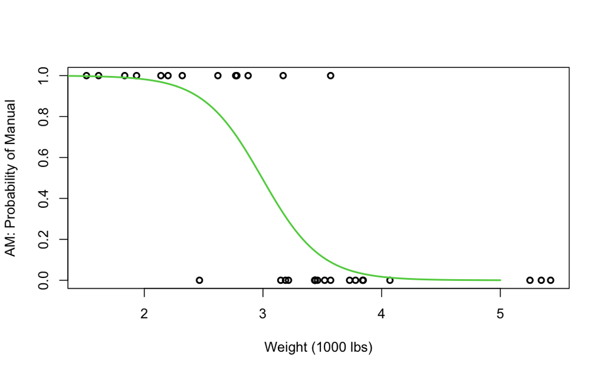

```r
plot(mtcars$wt, mtcars$am,xlab="Weight (1000 lbs)",
ylab="AM: Probability of Manual",lwd =2, cex = 0.9)
g = glm(formula = am ~ wt, data = mtcars, family =
binomial)
yweight <- predict(g, list(wt = seq(1, 5, 0.01)),
type="response")
lines(seq(1, 5, 0.01), yweight, lwd =2, col =3)
```

### PITFALLS

- Don’t try to extrapolate from fitted polynomials.
- Higher-order polynomials are great fits to the data at hand. They can often overfit the data. But predictions or extrapolations for values of 𝑥 outside of its range will often be incorrect and invalid.